# STAR Dataset Practice Project

Ishita Dutta, 918193342

02/04/2021

# Abstract

# Introduction

We are looking at the data from project STAR, an experiment conducted in Tennessee seeing how student testing scores are impacted by class size and teacher aid across multiple grades.

In this project, we will be focusing only on students in grade 1 and looking at specifically their math test scores for. Here, we will try to answer whether class size really mattered in terms of scores for these first graders. In the case that a different class size really produced significantly differing results, we then want to look at which class size produces the most optimal conditions. In simpler terms, we want to see which class size ends up producing the highest math results amongst the first graders.

# Background

This is a part of the original report done between 1985 and 1989 [(source)](https://www.rdocumentation.org/packages/AER/versions/1.2-9/topics/STAR) in which multiple grades over a range of subjects were involved, and the conclusions even included which connotations of students benefited most from which class size. This data was collected from 79 schools over 4 years and not only collected average score, but the demographic and socioeconomic factors of every teacher and student per school.The sample size was kept large to avoid confounding in terms of the demographics, as well as avoiding the problem in size reduction by student movement.

Overall, the results showed higher scores in smaller classes across average scores of all subjects. Influenced by the original project, the State of Tennessee decided to launch Project Challenge, in which it funded counties for reduced class sizes across grades K-3.

Though our analysis for this project is not this deep, we are looking forward to telling which class size is best for children trying to score optimally in mathematics in the first grade, provided that there really is a difference in score with the class size to begin with.

# Descriptive analysis

```r
library(tidyverse)
library(AER)
library(STAR)
#Looking at the columns of the original STAR Dataset
data("STAR")
data9 = STAR
```

```r
#Setting our data based on what we will need to complete analysis.
avai_id = which(!is.na(data9$math1))
data1 = data9[avai_id,c("math1", "schoolid1", "star1", "experience1", "tethnicity1")]
```

```r
#setting summary statistics
data2 = data1 %>%
          group_by(schoolid1,star1,experience1,tethnicity1)  %>%
          summarise(mean_score = mean(math1),
                    schoolid1 = unique(schoolid1),
                    star1 = unique(star1),
                    experience1 = unique(experience1),
                    tethnicity1 = unique(tethnicity1))
#summarized table
tail(data2)
```

```
## # A tibble: 6 × 5
## # Groups:   schoolid1, star1, experience1 [6]
##   schoolid1 star1        experience1 tethnicity1 mean_score
##   <fct>     <fct>              <int> <fct>            <dbl>
## 1 79        small                 15 cauc              523.
## 2 79        small                 16 cauc              537.
## 3 79        regular+aide          21 cauc              537.
## 4 80        regular                2 cauc              529.
## 5 80        small                  8 cauc              556.
## 6 80        regular+aide          12 cauc              540.
```

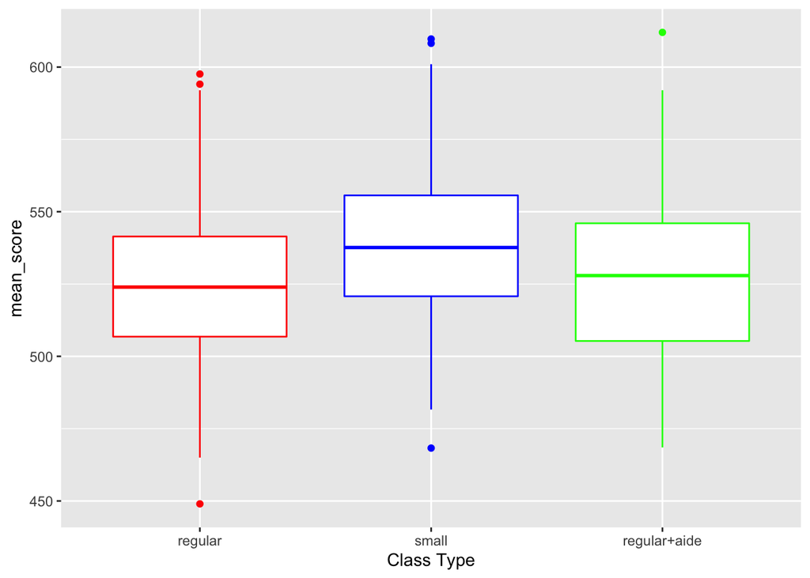

```r
#plotting summary statistics in the form of box plots.
ggplot(data=data2, mapping=aes(x=star1, y=mean_score)) +
  geom_boxplot(color = c("red", "blue", "green")) +
  xlab("Class Type")
```

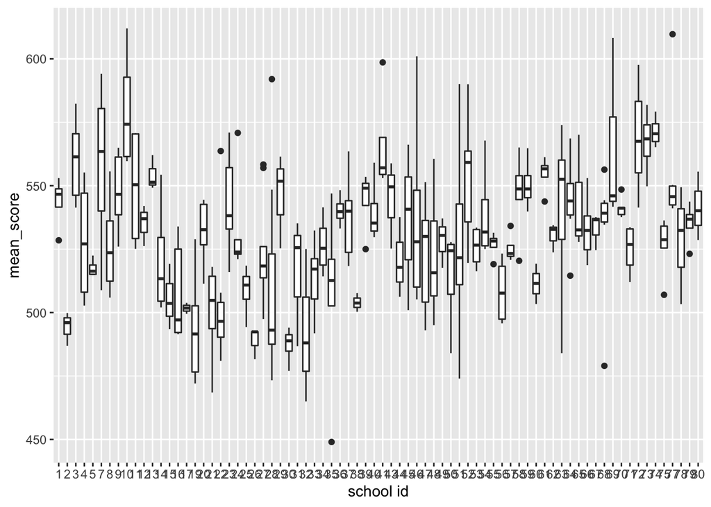

```r
ggplot(data=data2, mapping=aes(x=schoolid1, y=mean_score)) +
  geom_boxplot() +
  xlab("school id")
```

```r
#overall summary numbers
tmp = data2 %>%
        group_by(schoolid1) %>%
        summarise(sch_mean=mean(mean_score))
summary(tmp$sch_mean)
```

```
##    Min. 1st Qu.  Median    Mean 3rd Qu.    Max.
##   487.2   517.1   531.8   531.2   543.8   580.0
```

I chose the boxplot and mean as they are generally good measures of center. The mean gives an average value over each group as an observation average, while the boxplots help show spread as well as outliers.

# Inferential analysis

```r
model1 = aov(mean_score~schoolid1+star1, data=data2)
summary(model1)
```

```
##              Df Sum Sq Mean Sq F value   Pr(>F)
## schoolid1    75 152483    2033   5.355  < 2e-16 ***
## star1         2  14552    7276  19.164 1.54e-08 ***
## Residuals   288 109346     380
## ---
## Signif. codes:  0 '***' 0.001 '**' 0.01 '*' 0.05 '.' 0.1 ' ' 1
```

```r
TukeyHSD(model1, "star1")
```

```
##   Tukey multiple comparisons of means
##     95% family-wise confidence level
##
## Fit: aov(formula = mean_score ~ schoolid1 + star1, data = data2)
##
## $star1
##                            diff        lwr       upr     p adj
## small-regular         13.727207   8.000206 19.454207 0.0000001
## regular+aide-regular   1.983636  -3.999329  7.966601 0.7149492
## regular+aide-small   -11.743571 -17.715861 -5.771281 0.0000163
```

The two models above show high significance in the class size. This is because the ANOVA model shows p-values much more significant than if we were to run a alpha = 0.05 significance test.

The Tukey’s test shows us the idea of which class size is most optimal for math in the first grade. Going on a case-by-case analysis, the most optimal class is the small class size when compared to the other class sizes. This is highlighted because when the small class size is involved, 0 is not in the interval and the p adj value is much more significant than the alpha = 0.05 value generally run in a Tukey’s test. The only one not significant is the regular/regular with aide comparison, which also has 0 in the interval. This can only mean that it is the small class size that is causing such a drastic change in the results.

# Sensitivity analysis

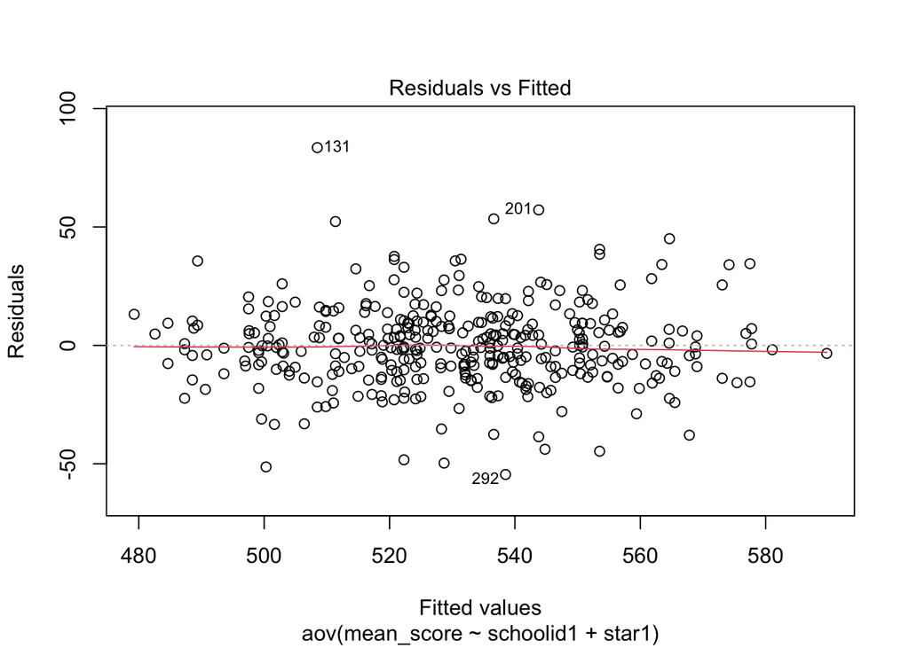

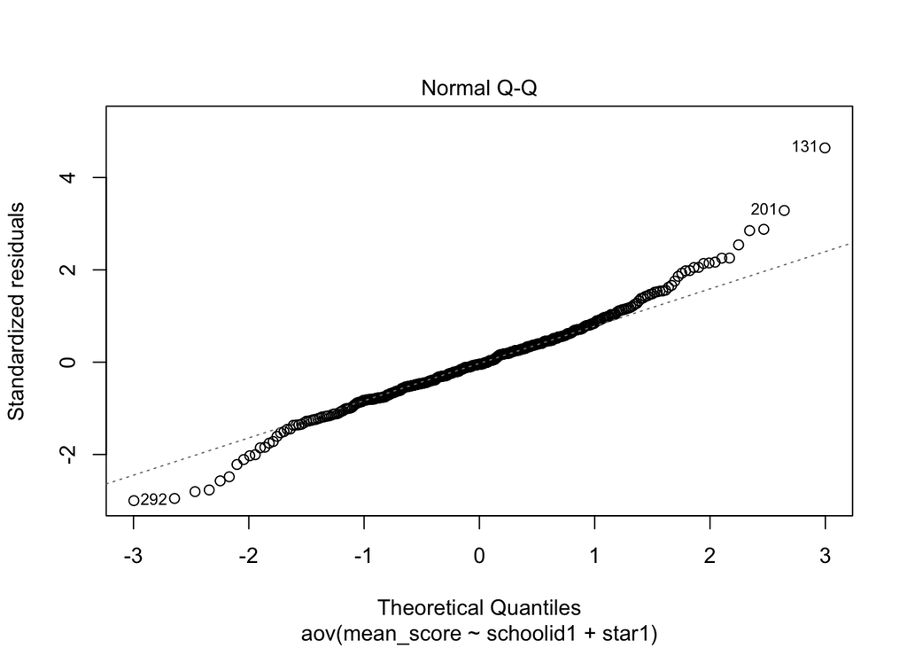

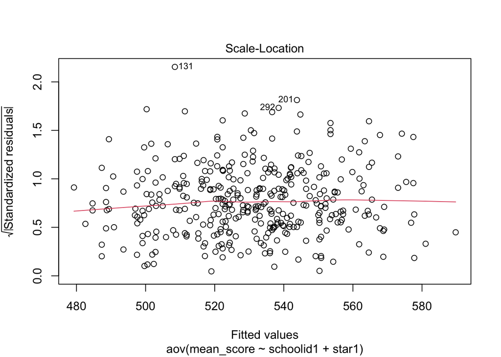

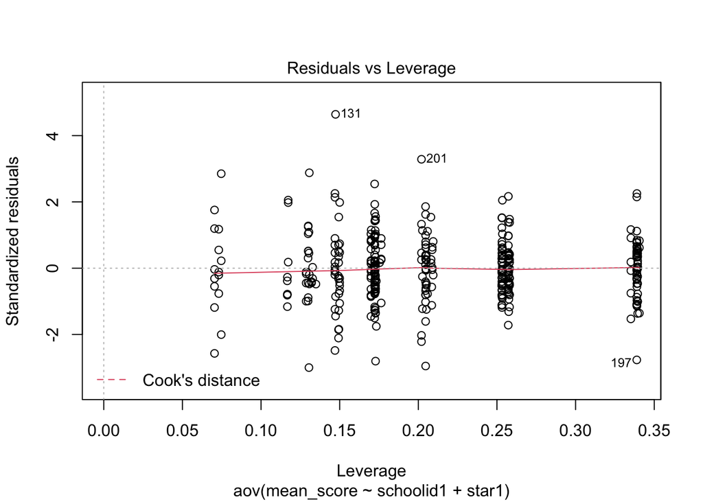

```r
plot(model1)
```

# Discussion

As mentioned in the background of the project, the State of Tennessee launched Project Challenge from the results of the original study, which was to reduce class sizes in the grades K - 3 in the 16 poorest counties of the state. From our analysis, we have also found the same, in which the small class sizes benefit the grade 1 math test scores the most. In the context of classrooms, we can infer this is because every student has more time to ask questions in a smaller class size, and therefore is set up for better comprehension of the given topics. Further policy making can be seen in the future, especially if the study is repeated in a place like California, where populations are higher.

# Acknowledgement

Did not discuss project with other people outside class.

# Reference

Boyd-Zaharias, Jayne. “Project STAR - The Story of the Tennessee Class-Size Study.” American Federation of Teachers, https://www.aft.org/sites/default/files/periodicals/STARSummer99.pdf.